# Coursera Project: Predict if barbell lifts are properly done

Gurmeet Singh

January 13, 2016

## Introduction:

In this project, the goal is to *predict how well someone is performing a barbell lift* based on data collected during a study. The data from accelerometers on the belt, forearm, arm, and dumbell of 6 participants was used to quantify how well they are performing barbell lifts. This was done by having them perform the lifts correctly and incorrectly in 5 different ways and labelling each observation (corresponding to a lift) labeled appropriately in the data set. More information is available from the website here: http://groupware.les.inf.puc-rio.br/har (see the section on the Weight Lifting Exercise Dataset). [The training data](https://d396qusza40orc.cloudfront.net/predmachlearn/pml-training.csv) [The test data](https://d396qusza40orc.cloudfront.net/predmachlearn/pml-testing.csv)

### How the model was built

I decided to try a “Random Forest” learning method since it is very tolerant of missing data and noise in general which appeared to be the case for this dataset when looking at the `summary()` results on the data. This method can also provide feedback on what features were more important.

Here are the steps to read data, build model and predict:

```r
library(h2o)
training <- read.csv("pml-training.csv")
testing <- read.csv("pml-testing.csv")

#Discard columns 1-7 (not observations)
train <- training[,-c(1:7)]
test <- testing[,-c(1:7)]

#Remove columns not to be used as features
features <- colnames(train)[!(colnames(train) %in% c("classe"))]

#Include the prediction column in training set only
train <- train[,c("classe", features)]
test <- test[,c(features)]

#Use h2o package for prediction, I've used this
#frequently in the past for Kaggle comptetitions.
h2o.init(nthreads=18,max_mem_size='48G')
hexTrain <- as.h2o(train)

cat("Fitting...\n")
rfHex <- h2o.randomForest(x=features,
                          y="classe",
                          ntrees = 200,
                          max_depth = 16,
                          nbins_cats = 6,
                          training_frame=hexTrain)
summary(rfHex)

#Predict on test set
testHex <- as.h2o(test)
predictions<- as.data.frame(h2o.predict(rfHex,testHex))
```

```r
#Show the predicted values
predictions[[1]]
```

```
##  [1] B A B A A E D B A A B C B A E E A B B B
## Levels: A B C D E
```

The following plots/data show that some variable are much more important than others.

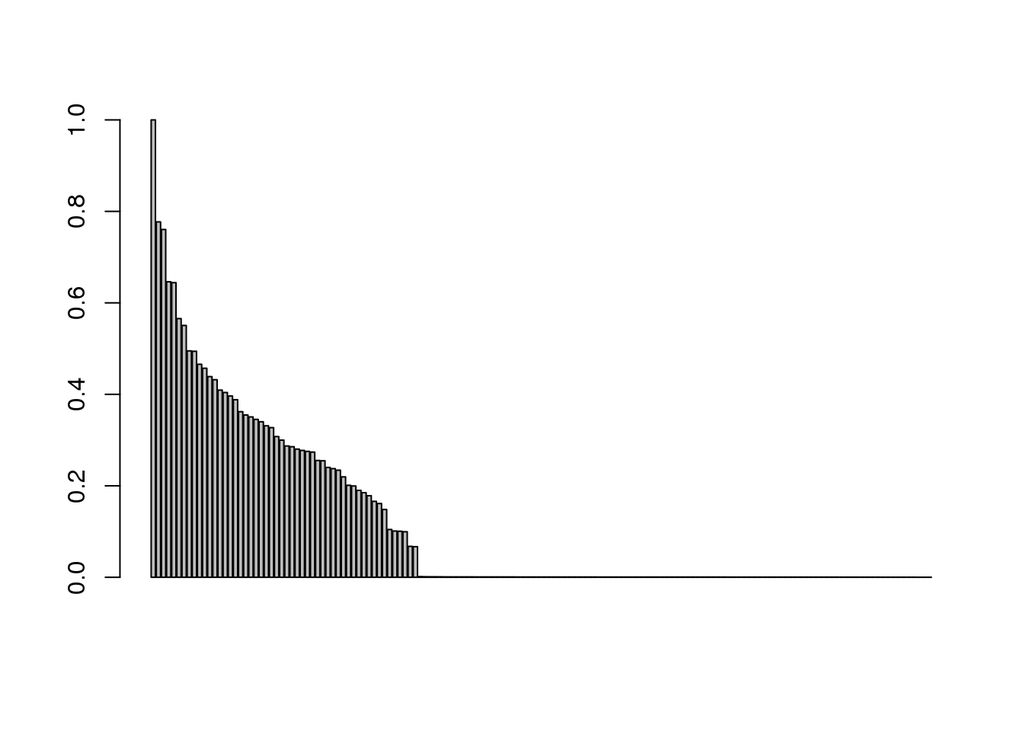

```r
#Display variable importance as bar plot
v <- rfHex@model$variable_importances
barplot(v$scaled_importance)
```

```r
# This shows that the variable importance falls off sharply
# after the first 50
nrow(v[v$scaled_importance > 0.1,]); nrow(v[v$scaled_importance > 0.01,])
```

```
## [1] 49
```

```
## [1] 52
```

```r
#Some of the most important features
v[v$scaled_importance > 0.1,]$variable[1:10]
```

```
##  [1] "roll_belt"         "magnet_dumbbell_z" "pitch_forearm"
##  [4] "roll_forearm"      "yaw_belt"          "magnet_dumbbell_y"
##  [7] "magnet_dumbbell_x" "magnet_belt_y"     "pitch_belt"
## [10] "accel_belt_z"
```

I did a prediction with just the top 50 most important features and still obtained the same (perfect) prediction results on the test set.

### How was cross validation done

```r
inTrain <- createDataPartition(y=train$classe, p=0.667, list=F)
train <- train[inTrain,]
cv <- train[-inTrain,]
#Trin the model here, just as done previously.
cvHex <- as.h2o(cv)
cvpred<- as.data.frame(h2o.predict(rfHex,cvHex))
missClass <- function(values,prediction){ (sum(predictions == values))/length(values)}
missClass(as.character(cv$classe),as.character(cvpred$predict))
```

```
# [1] 0.001605873
```

### Other notes

The prediction computation using 152 column predictors runs in less than two minutes on a 24 cpu core, 48GB linux server. With reduced (50) predictors, in one minute with same accuracy.

The content of this report is authored in RStudio using R Markdown format and converted to HTML using “Knit HTML” command. The R Markdown file itself can be found on[GitHub](https://github.com/swiftgurmeet/coursera-pml-project)